# 水系粘度解析

Rによる粘度データの解析

○解析の手順 品質管理dbの“粘度データ”テーブルからデータ取得

```r
library("RODBC")
ch<-odbcConnect("qc")
t <- getVisData()
names(t)<-c("day", "pcode", "lot", "dl", "dh", "wl", "wh", "al", "ah")
hiravisiv<-sqlQuery(ch, "select * from hiravisiv")
```

```
closing unused RODBC handle 14
```

```r
names(hiravisiv)[6]<-"day"
t<-merge(hiravisiv, t, all.y=T)
```

```
closing unused RODBC handle 11
```

1.まずDBのサニティチェックを実施し、おかしな粘度値は修正しておく

boxplotを使ったサニティチェック。外れ値を抽出している。チェックしたい列ごとに書き換えて実行する

```r
san<-tapply(t$ah, t$pcode, FUN=function(x){out <- boxplot(x, plot=F)$out; out/mean(x, na.rm=T)})
cpy(unlist(san))
```

そのままでは修正すべきtypoや換算ミスが外れ値に埋もれて見えてこないので、平均で割っている。結果をExcelでソートして確認する

粘度規格は同じ製造コードで2件(HAC, HAU)入っているものがあるので注意が必要 粘度規格表をそのままコピペしてから、重複行を除去する。だが日本語を含むデータをRStudioで pstしようとするとエラーになることがあった。その場合pstは裸のRで行わなければならない。

```r
spec <- pst()
spec<-unique(spec[,-2:-3])
names(spec) <- c("pcode","db","dt","wb","wt","ab","at")
```

全データにpci()を適用する。最低3ロット必要。ものによって異常な結果になるので、ここでは4ロット以上としている。dh==NAのデータがあるので、それを削除してから処理する。

```r
t.org <- t
t <- ss(t, !is.na(dh),)
tgt <- as.numeric(unlist(dimnames(table(t$pcode)[table(t$pcode)>3])))
pcires <- sapply(tgt, pci, verbose=F)
```

```
Error in specv[, 6] : incorrect number of dimensions
```

現行規格がNAの場合はpciもNAになる。また規格が0-0になっているものがあり、その場合pciも0になる。

工程能力指数の度数分布

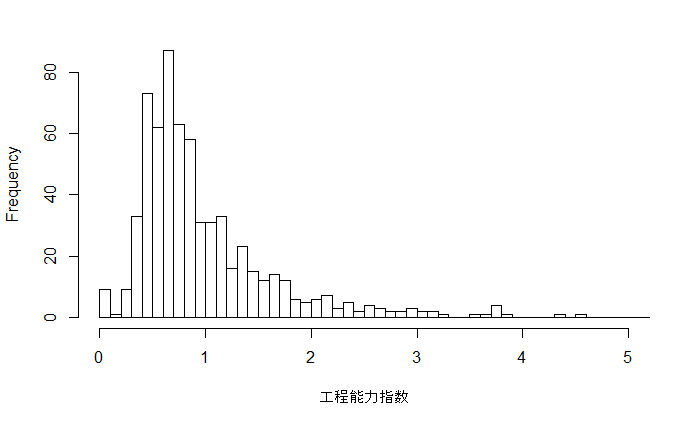

```r
hist(dfpcires$pci, br=500, xlim=c(0,5), main="", xlab="工程能力指数")
```

粘測を省くために、チクソの変動を評価する

```r
ti <- within(t, {td <- dl/dh; tw <- wl/wh; ta <- al/ah; tdw <- tw/td; tda <- ta/td})
tihwc <- ss(merge(pcode, ti), series=="HWC", c(pcode, series, name, td, tw, ta, tdw, tda))
sdtdw <- tapply(ti$tdw, ti$pcode, function(x) sd(x, na.rm=T)/mean(x, na.rm=T))
sdtdwhwc <- tapply(tihwc$tdw, tihwc$pcode, function(x) sd(x, na.rm=T)/mean(x, na.rm=T))
sdtdahwc <- tapply(tihwc$tda, tihwc$pcode, function(x) sd(x, na.rm=T)/mean(x, na.rm=T))
```

各変動係数のプロット

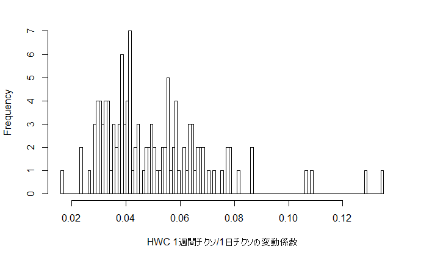

```r
hist(sdtdwhwc, br=100, xlab="HWC 1週間チクソ/1日チクソの変動係数", main="")
```

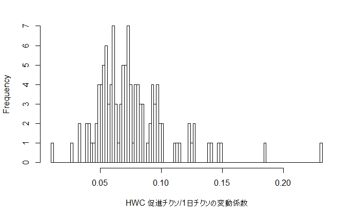

```r
hist(sdtdahwc, br=100, xlab="HWC 促進チクソ/1日チクソの変動係数", main="")
```

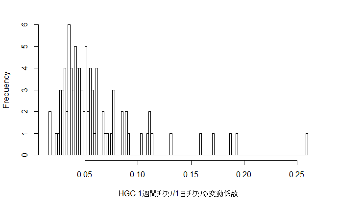

```r
hist(sdtdwhgc, br=100, xlab="HGC 1週間チクソ/1日チクソの変動係数", main="")
```

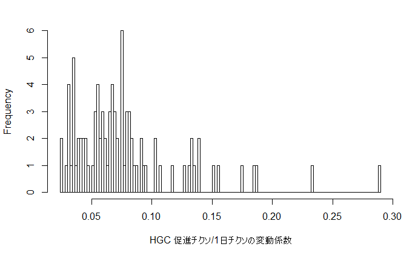

```r
hist(sdtdahgc, br=100, xlab="HGC 促進チクソ/1日チクソの変動係数", main="")
```

HWCの1dと1wのチクソ比のばらつきの最大のものについて、チクソ比の信頼区間を求める

```r
which(sdtdwhwc == max(sdtdwhwc, na.rm=T))
```

```
530388
    35
```

```r
t.test(ss(ti, pcode==530388, tdw))
```

```
    One Sample t-test

data:  ss(ti, pcode == 530388, tdw)
t = 41.307, df = 30, p-value < 2.2e-16
alternative hypothesis: true mean is not equal to 0
95 percent confidence interval:
 0.9836885 1.0860170
sample estimates:
mean of x
 1.034853
```

```r
which(sdtdwhgc == max(sdtdwhgc, na.rm=T))
```

```
535487
    32
```

```r
t.test(ss(ti, pcode==535487, tdw))
```

```
    One Sample t-test

data:  ss(ti, pcode == 535487, tdw)
t = 16.397, df = 17, p-value = 7.475e-12
alternative hypothesis: true mean is not equal to 0
95 percent confidence interval:
 0.879149 1.138797
sample estimates:
mean of x
 1.008973
```

```r
which(sdtdahwc == max(sdtdahwc, na.rm=T))
```

```
530601
    52
```

```r
t.test(ss(ti, pcode==530601, tda))
```

```
    One Sample t-test

data:  ss(ti, pcode == 530601, tda)
t = 24.932, df = 32, p-value < 2.2e-16
alternative hypothesis: true mean is not equal to 0
95 percent confidence interval:
 1.102495 1.298666
sample estimates:
mean of x
  1.20058
```

```r
which(sdtdahgc == max(sdtdahgc, na.rm=T))
```

```
535487
    32
```

```r
t.test(ss(ti, pcode==535487, tda))
```

```
    One Sample t-test

data:  ss(ti, pcode == 535487, tda)
t = 14.68, df = 17, p-value = 4.357e-11
alternative hypothesis: true mean is not equal to 0
95 percent confidence interval:
 0.920095 1.228958
sample estimates:
mean of x
 1.074527
```

# 日付を数値型から日付型に変更する

# 予測を現在時点でなく、データの最新時点で実施する

sdtdw[!is.na(sdtdw) & sdtdw > 1]